# Machine Learning Prediction Project

Li Xiaohui

2015-08-23

## Intro

In this project, I will be using data from accelerometers on the belt, forearm, arm, and dumbell of 6 participants and quantify how well each participant did each activity. Participants were asked to perform barbell lifts correctly and incorrectly in 5 different ways. More information is available from the website here: http://groupware.les.inf.puc-rio.br/har (http://groupware.les.inf.puc-rio.br/har) (see the section on the Weight Lifting Exercise Dataset).

Load libraries and set seed to ensure reproducibility of results.

## Data preprocessing

In this section, #DIV/0! were removed and replaced with NA values and empty strings were replaced by NA values. Columns with every row being NA are removed from training and testing data. To make sure learned model can be applied to testing data, only complete cases are retained in both training and testing data sets. Finally, the common features in both training and testing data sets are used for training.

```r
pml_training <- read.csv(file="pml-training.csv", header=TRUE, na.strings=c("NA","#DIV/0!",""))
dim(pml_training)
```

```
## [1] 19622   160
```

```r
#summary(pml_training)

# function to remove columns with every row being NA
removeNAcols   <- function(x) { x[, colSums( is.na(x) ) < nrow(x) ] }

tr.na.rm <- removeNAcols(pml_training)

# only take the complete cases
tr.complete <- tr.na.rm[complete.cases(tr.na.rm), ]


pml_testing <- read.csv(file="pml-testing.csv", header=TRUE, na.strings=c("NA","#DIV/0!",""))

# only keep names that appear in training
names <- names(tr.na.rm)
names <- names[1: length(names)-1]
testing <- pml_testing[, names]

# remove columns with every row being NA
testing <- removeNAcols(testing)


# only keep columns that appear in testing
tr.complete <- tr.complete[ , c(names(testing), "classe")]

#split training into training and testing
inTrain <- createDataPartition(y=tr.complete$classe, p=0.6, list=FALSE)
tr.training <- tr.complete[inTrain, ]; tr.testing <- tr.complete[-inTrain, ]
```

## Fit a decision tree model

We fit a decision tree model.

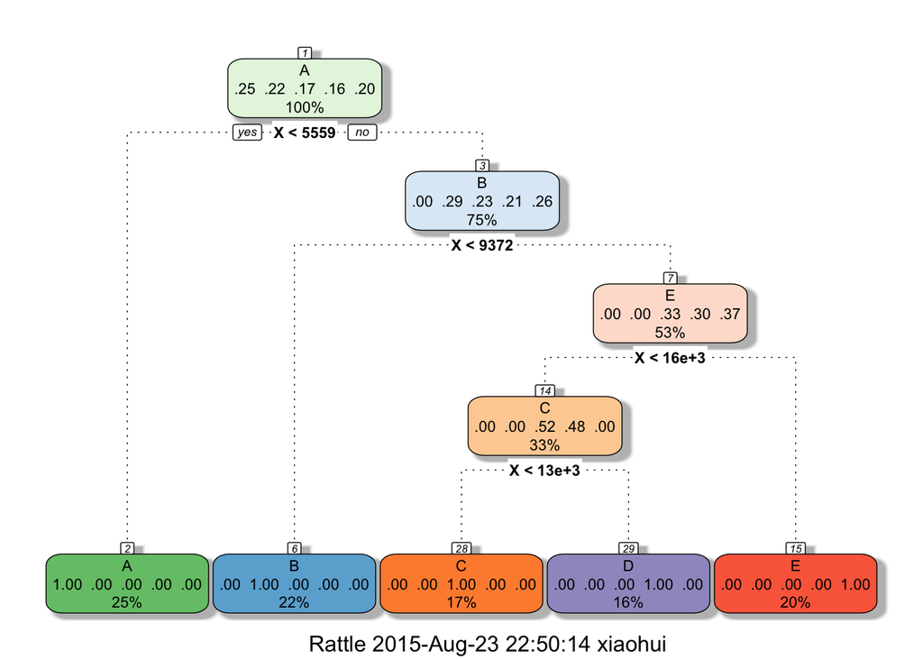

```r
treeFit<- rpart(classe ~ . , data=tr.training, method="class")

#plot(treeFit)
fancyRpartPlot(treeFit)
```

```r
tr.testing$tree_pred <- predict(treeFit, tr.testing, type="class")

confusionMatrix(tr.testing$tree_pred, tr.testing$classe)
```

```
## Confusion Matrix and Statistics
##
##           Reference
## Prediction  A  B  C  D  E
##          A 21  0  0  0  0
##          B  0 19  0  0  0
##          C  0  0 14  0  0
##          D  0  0  0 14  0
##          E  0  0  0  0 17
##
## Overall Statistics
##
##                Accuracy : 1
##                  95% CI : (0.958, 1)
##     No Information Rate : 0.247
##     P-Value [Acc > NIR] : <2e-16
##
##                   Kappa : 1
##  Mcnemar's Test P-Value : NA
##
## Statistics by Class:
##
##                      Class: A Class: B Class: C Class: D Class: E
## Sensitivity             1.000    1.000    1.000    1.000      1.0
## Specificity             1.000    1.000    1.000    1.000      1.0
## Pos Pred Value          1.000    1.000    1.000    1.000      1.0
## Neg Pred Value          1.000    1.000    1.000    1.000      1.0
## Prevalence              0.247    0.224    0.165    0.165      0.2
## Detection Rate          0.247    0.224    0.165    0.165      0.2
## Detection Prevalence    0.247    0.224    0.165    0.165      0.2
## Balanced Accuracy       1.000    1.000    1.000    1.000      1.0
```

The results is good with accuracy being 1.

## Fit a random forest model

With random forest, we do repeated data cross validation by dividnig data into 5 groups and repeat 3 times.

```r
cvCtrl <- trainControl(method = "repeatedcv",
                           number = 5,
                           repeats = 3)

rfFit<- train(classe ~ . , data=tr.training, method="rf", trControl=cvCtrl, importance=TRUE)

tr.testing$dt_pred <- predict(rfFit, tr.testing)
confusionMatrix(tr.testing$dt_pred, tr.testing$classe)
```

```
## Confusion Matrix and Statistics
##
##           Reference
## Prediction  A  B  C  D  E
##          A 21  0  0  0  0
##          B  0 19  0  0  0
##          C  0  0 14  0  0
##          D  0  0  0 14  0
##          E  0  0  0  0 17
##
## Overall Statistics
##
##                Accuracy : 1
##                  95% CI : (0.958, 1)
##     No Information Rate : 0.247
##     P-Value [Acc > NIR] : <2e-16
##
##                   Kappa : 1
##  Mcnemar's Test P-Value : NA
##
## Statistics by Class:
##
##                      Class: A Class: B Class: C Class: D Class: E
## Sensitivity             1.000    1.000    1.000    1.000      1.0
## Specificity             1.000    1.000    1.000    1.000      1.0
## Pos Pred Value          1.000    1.000    1.000    1.000      1.0
## Neg Pred Value          1.000    1.000    1.000    1.000      1.0
## Prevalence              0.247    0.224    0.165    0.165      0.2
## Detection Rate          0.247    0.224    0.165    0.165      0.2
## Detection Prevalence    0.247    0.224    0.165    0.165      0.2
## Balanced Accuracy       1.000    1.000    1.000    1.000      1.0
```

We also want to investigate the variable importances by plotting the importance levels of variables.

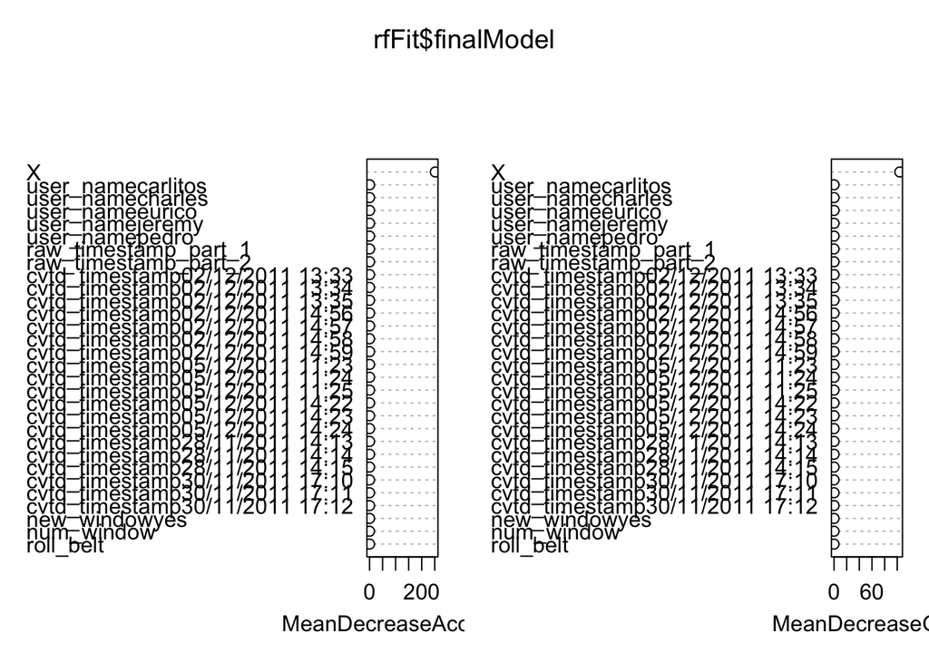

```r
varImpPlot(rfFit$finalModel)
```

## Generating submission files

Function to generate files with predictions to submit for assignment

```r
pred <- predict(rfFit, testing, type = "class")

pml_write_files = function(x){
  n = length(x)
  for(i in 1:n){
    filename = paste0("problem_id_",i,".txt")
    write.table(x[i],file=filename,quote=FALSE,row.names=FALSE,col.names=FALSE)
  }
}

pml_write_files(pred)
```